# lessig-emily-ada-homework-3

Emily Lessig

4/9/2021

Challenge 1

```r
library(readr)
library(tidyverse)
```

```r
library(lmodel2)
library(manipulate)
library(patchwork)
library(infer)
library(ggplot2)
library(broom)
library(cowplot)
library(gridExtra)
library(tidyr)
library(dplyr)
library(tibble)


f <- "https://raw.githubusercontent.com/difiore/ADA-datasets/master/KamilarAndCooperData.csv"

d <- read_csv(f, col_names = TRUE)
head(d)
```

```
## # A tibble: 6 x 44
##   Scientific_Name Family Genus Species Brain_Size_Spec… Brain_Size_Fema…
##   <chr>           <chr>  <chr> <chr>              <dbl>            <dbl>
## 1 Allenopithecus… Cerco… Alle… nigrov…             58.0             53.7
## 2 Allocebus_tric… Cerco… Allo… tricho…             NA               NA
## 3 Alouatta_belze… Ateli… Alou… belzeb…             52.8             51.2
## 4 Alouatta_caraya Ateli… Alou… caraya              52.6             47.8
## 5 Alouatta_guari… Ateli… Alou… guariba             51.7             49.1
## 6 Alouatta_palli… Ateli… Alou… pallia…             49.9             48.0
## # … with 38 more variables: Brain_size_Ref <chr>, Body_mass_male_mean <dbl>,
## #   Body_mass_female_mean <dbl>, Mass_Dimorphism <dbl>, Mass_Ref <chr>,
## #   MeanGroupSize <dbl>, AdultMales <dbl>, AdultFemale <dbl>,
## #   AdultSexRatio <dbl>, Social_Organization_Ref <chr>,
## #   InterbirthInterval_d <dbl>, Gestation <dbl>, WeaningAge_d <dbl>,
## #   MaxLongevity_m <dbl>, LitterSz <dbl>, Life_History_Ref <chr>,
## #   GR_MidRangeLat_dd <dbl>, Precip_Mean_mm <dbl>, Temp_Mean_degC <dbl>,
## #   AET_Mean_mm <dbl>, PET_Mean_mm <dbl>, Climate_Ref <chr>,
## #   HomeRange_km2 <dbl>, HomeRangeRef <chr>, DayLength_km <dbl>,
## #   DayLengthRef <chr>, Territoriality <dbl>, Fruit <dbl>, Leaves <chr>,
## #   Fauna <chr>, DietRef1 <chr>, Canine_Dimorphism <dbl>,
## #   Canine_Dimorphism_Ref <chr>, Feed <dbl>, Move <dbl>, Rest <dbl>,
## #   Social <dbl>, Activity_Budget_Ref <chr>
```

```r
names(d)
```

```
##  [1] "Scientific_Name"         "Family"
##  [3] "Genus"                   "Species"
##  [5] "Brain_Size_Species_Mean" "Brain_Size_Female_Mean"
##  [7] "Brain_size_Ref"          "Body_mass_male_mean"
##  [9] "Body_mass_female_mean"   "Mass_Dimorphism"
## [11] "Mass_Ref"                "MeanGroupSize"
## [13] "AdultMales"              "AdultFemale"
## [15] "AdultSexRatio"           "Social_Organization_Ref"
## [17] "InterbirthInterval_d"    "Gestation"
## [19] "WeaningAge_d"            "MaxLongevity_m"
## [21] "LitterSz"                "Life_History_Ref"
## [23] "GR_MidRangeLat_dd"       "Precip_Mean_mm"
## [25] "Temp_Mean_degC"          "AET_Mean_mm"
## [27] "PET_Mean_mm"             "Climate_Ref"
## [29] "HomeRange_km2"           "HomeRangeRef"
## [31] "DayLength_km"            "DayLengthRef"
## [33] "Territoriality"          "Fruit"
## [35] "Leaves"                  "Fauna"
## [37] "DietRef1"                "Canine_Dimorphism"
## [39] "Canine_Dimorphism_Ref"   "Feed"
## [41] "Move"                    "Rest"
## [43] "Social"                  "Activity_Budget_Ref"
```

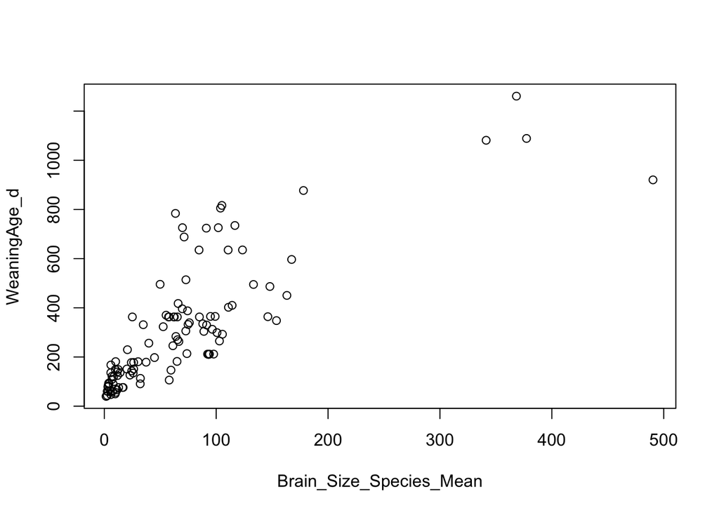

```r
plot(data=d, WeaningAge_d~Brain_Size_Species_Mean)
```

```r
#the end aim is to fit a simple linear regression model to predict weaning age from species' brain size. Do the following for both weaning age ~brain size and log(weaning age) ~log(brain size)

m <- lm(WeaningAge_d~Brain_Size_Species_Mean, data=d)
m
```

```
##
## Call:
## lm(formula = WeaningAge_d ~ Brain_Size_Species_Mean, data = d)
##
## Coefficients:
##             (Intercept)  Brain_Size_Species_Mean
##                 132.464                    2.637
```

```r
names(m)
```

```
##  [1] "coefficients"  "residuals"     "effects"       "rank"
##  [5] "fitted.values" "assign"        "qr"            "df.residual"
##  [9] "na.action"     "xlevels"       "call"          "terms"
## [13] "model"
```

```r
w2 <-log(d$WeaningAge_d)
b2 <-log(d$Brain_Size_Species_Mean)

m2 <- lm(w2 ~b2, data=d)

m2
```

```
##
## Call:
## lm(formula = w2 ~ b2, data = d)
##
## Coefficients:
## (Intercept)           b2
##      3.3698       0.5712
```

Fit the regression model and using ggplot2 produce a scatterplot with the fitted line superimposed upon the data. Append the fitted model equation to your plot

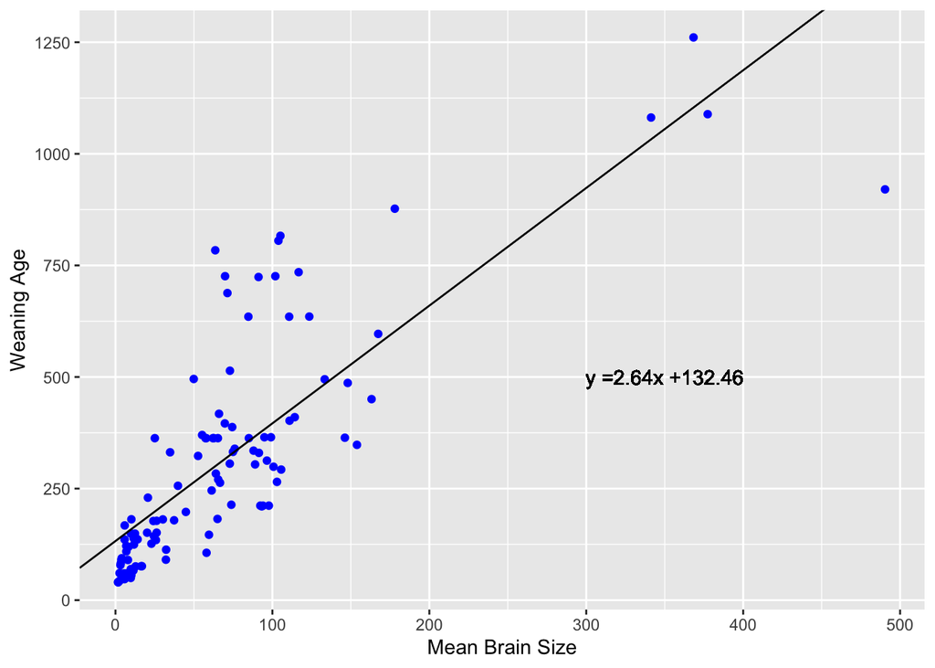

```r
#untransformed

p1 <- ggplot(data = d, aes(x=Brain_Size_Species_Mean, y=WeaningAge_d))+
  geom_point(color="blue")+
  geom_abline(slope = m$coefficients[2], intercept = m$coefficients[1])+
  geom_text(x=350, y=500, label=paste0("y =", round(m$coefficients[2], digits = 2), "x +", round(m$coefficients[1], digits = 2))) + labs(y="Weaning Age", x="Mean Brain Size")

p1
```

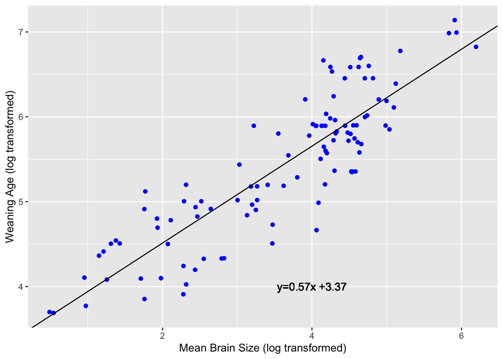

```r
#Log transformed

p2 <- ggplot(data=d, aes(x=b2, y=w2))+
   geom_point(color="blue")+
   geom_abline(slope = m2$coefficients[2], intercept = m2$coefficients[1])+
  geom_text(x=4, y=4, label=paste0("y=", round(m2$coefficients[2], digits=2),"x +", round(m2$coefficients[1],
  digits = 2))) + labs(y="Weaning Age (log transformed)", x="Mean Brain Size (log transformed)")



p2
```

Identify and interpret the point estimate of the slope (B1) as well as the outcome of the test associated with the hypotheses H0: B1 =0, HA: B1 != 0. Also, find a 90% CI for the slope B1 parameter

```r
# weaning age ~ brain size

h <- m$coefficients
beta0 <- as.numeric(h[1])
beta1 <- as.numeric(h[2])
beta1
```

```
## [1] 2.637107
```

```r
CI <- confint(m, level = 0.9)
CI_beta1 <- CI[2, ]
CI_beta1
```

```
##      5 %     95 %
## 2.330607 2.943606
```

```r
#log(weaning age)~ log(brain size)

hLog <- m2$coefficients
Log_beta0 <- as.numeric(hLog[1])
Log_beta1 <- as.numeric(hLog[2])
Log_beta1
```

```
## [1] 0.57116
```

```r
CI_Log <- confint(m2, level = 0.9)
Log_CI_Beta1 <- CI_Log[2, ]
Log_CI_Beta1
```

```
##       5 %      95 %
## 0.5203774 0.6219426
```

using your model, add lines for the 90% confidence and prediction interval bands on the plot, and add a legend to differentiate between the lines

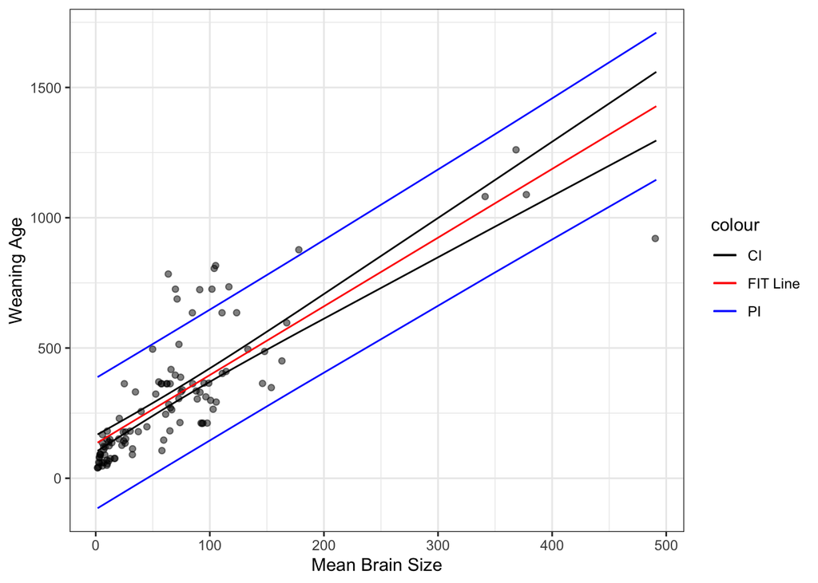

```r
ci <- predict(m, newdata = data.frame(Brain_Size_Species_Mean=d$Brain_Size_Species_Mean),
              interval="confidence", level=0.9)

ci <- data.frame(ci)

ci <- cbind(d$Brain_Size_Species_Mean, ci)
names(ci) <- c("brain", "c.fit", "c.lwr", "c.upr")

pi <- predict(m, newdata = data.frame(Brain_Size_Species_Mean=d$Brain_Size_Species_Mean),
              interval = "prediction", level=0.9)

pi <-data.frame(pi)

pi <-cbind(d$Brain_Size_Species_Mean, pi)
names(pi) <- c("brain", "p.fit", "p.lwr", "p.upr")

p3 <- ggplot(data = d, aes(x=Brain_Size_Species_Mean, y=WeaningAge_d), na.rm=TRUE)+
  geom_point(alpha=0.5)+
  geom_line(data = ci, aes(x=brain, y=c.fit, color="FIT Line"))+
   geom_line(data = ci, aes(x=brain, y=c.lwr, color="CI"))+
   geom_line(data = ci, aes(x=brain, y=c.upr, color="CI"))+
   geom_line(data = pi, aes(x=brain, y=p.lwr, color="PI"))+
   geom_line(data = pi, aes(x=brain, y=p.upr, color="PI"))+
  scale_color_manual(values = c("black", "red", "blue"))+
  labs(y="Weaning Age", x="Mean Brain Size") +theme_bw()

p3
```

```r
ci_log <- predict(m2, newdata = data.frame(Brain_Size_Species_Mean=d$Brain_Size_Species_Mean),
              interval="confidence", level=0.9)

ci_log <- data.frame(ci_log)

ci_log <- cbind(d$Brain_Size_Species_Mean, ci_log)
names(ci_log) <- c("logbrain", "c.fitLog", "c.lwrLog", "c.uprLog")

pi_Log <- predict(m2, newdata = data.frame(Brain_Size_Species_Mean=d$Brain_Size_Species_Mean),
              interval = "prediction", level=0.9)

pi_Log <-data.frame(pi_Log)

pi_Log <-cbind(d$Brain_Size_Species_Mean, pi_Log)
names(pi_Log) <- c("logbrain", "p.fitLog", "p.lwrLog", "p.uprLog")


p4 <- ggplot(data = d, aes(x= b2, y=w2), na.rm=TRUE)+
  geom_point(alpha=0.5)+
  geom_line(data = ci_log, aes(x=logbrain, y=c.fitLog, color="FIT Line"))+
  geom_line(data = ci_log, aes(x=logbrain, y=c.lwrLog, color="CI"))+
  geom_line(data = ci_log, aes(x=logbrain, y=c.uprLog,"CI"))+
  geom_line(data = pi_Log, aes(x=logbrain, y=p.lwrLog, color="PI"))+
  geom_line(data = pi_Log, aes(x=logbrain, y=p.uprLog, color="PI"))+
scale_color_manual(values = c("black", "red", "blue"))+
  labs(y="Weaning Age", x="Mean Brain Size") +theme_bw()
```

Produce a point estimate and associated 90% prediction interval for the weaning age of a species whose brain weight s 750 gm. Do you trust the model to predict observations accurately for this value of the explanatory variable? Why/why not?

```r
point_est <- predict(m,
                     newdata = data.frame(Brain_Size_Species_Mean = 750),
                     interval = "confidence", level = 0.9)

point_est
```

```
##        fit     lwr      upr
## 1 2110.294 1900.04 2320.548
```

```r
#This value is higher than the observed mean brain sizes, so I would not think it to be accurate/I would not trust it accurately predict observations
```

Challenge 2

Using the Kamilar and Cooper data, run a linear regression looking at log(Mean Group Size) in relation to log(Body mass female mean) and report your B coefficients (slop and intercept)

```r
regress <- lm(log(MeanGroupSize) ~ log(Body_mass_female_mean), data = d)

summary(regress)
```

```
##
## Call:
## lm(formula = log(MeanGroupSize) ~ log(Body_mass_female_mean),
##     data = d)
##
## Residuals:
##      Min       1Q   Median       3Q      Max
## -2.85428 -0.66210  0.03604  0.63941  2.51998
##
## Coefficients:
##                            Estimate Std. Error t value Pr(>|t|)
## (Intercept)                -1.77726    0.43752  -4.062 8.06e-05 ***
## log(Body_mass_female_mean)  0.50628    0.05563   9.102 8.08e-16 ***
## ---
## Signif. codes:  0 '***' 0.001 '**' 0.01 '*' 0.05 '.' 0.1 ' ' 1
##
## Residual standard error: 0.9373 on 140 degrees of freedom
##   (71 observations deleted due to missingness)
## Multiple R-squared:  0.3717, Adjusted R-squared:  0.3673
## F-statistic: 82.84 on 1 and 140 DF,  p-value: 8.078e-16
```

```r
#Beta coefficients

b <- regress$coefficients
beta0 <- as.numeric(b[1])
beta1 <- as.numeric(b[2])
coeff_Value <- c(beta0, beta1)
coeff_Type <- c("β0", "β1")
beta_coeff <- data.frame(coeff_Type, coeff_Value)
beta_coeff
```

```
##   coeff_Type coeff_Value
## 1         β0  -1.7772580
## 2         β1   0.5062813
```

Use bootstrapping to sample from the dataset 1000 times with replacement, each time fitting the same model and calculating the appropriate coefficients. Plot a histogram of these sampling distributions for  
β0 and β1 .

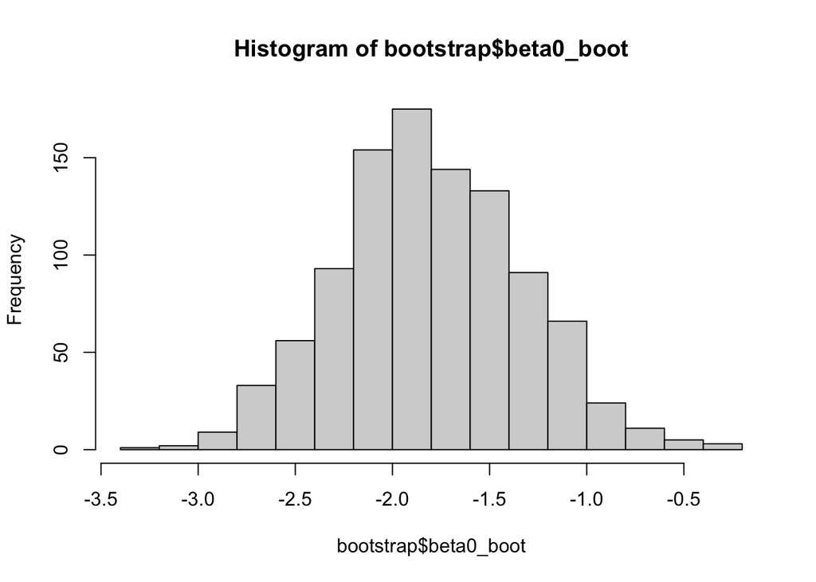

```r
#want this for the logged values

MeanGroupSize_Log <- log(d$MeanGroupSize)
BodyMass_Log <- log(d$Body_mass_female_mean)

d2 <- cbind(d, MeanGroupSize_Log, BodyMass_Log)

#now bootstrap

set.seed(1)
bootstrap <- data.frame(beta0_boot=1:100, beta1_boot = 1:1000)

#make it so each sample will be equivalent to the total number of observations in the dataset

n <- nrow(d2)
reps <-1000


for (i in 1:reps) {
  sample_d <-sample_n(d2, size = n, replace=TRUE)
  l4 <- lm(data = sample_d, formula = log(MeanGroupSize) ~ log(Body_mass_female_mean))
  l4.coeffs <- l4$coefficients
  beta0_boot <- as.numeric(l4.coeffs[1])
  beta1_boot <- as.numeric(l4.coeffs[2])
  bootstrap$beta0_boot[[i]] <- beta0_boot
  bootstrap$beta1_boot[[i]] <- beta1_boot


}

#Plot a histogram of these sampling distributions for β0 and β1 .

#beta0

hist(bootstrap$beta0_boot)
```

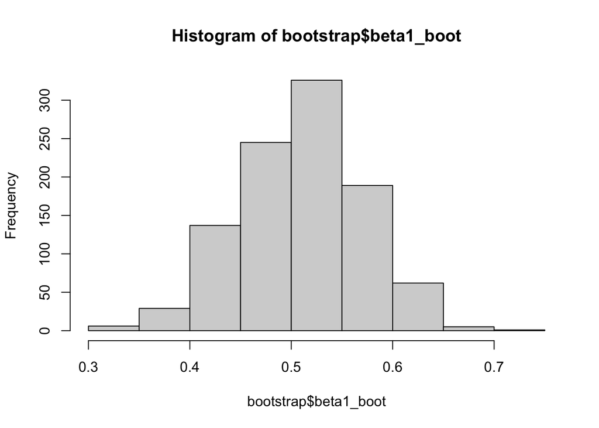

```r
#beta1

hist(bootstrap$beta1_boot)
```

Estimate the standard error for each of your B coefficients as the standard deviation of the sampling distribution from your bootstrap.

```r
se.beta0 <- sd(bootstrap$beta0_boot)
se.beta1 <- sd(bootstrap$beta1_boot)
bootstrapSE <- c(se.beta0, se.beta1)
```

Also determine the 95% CI for each of your B coefficients based on the appropriate quantiles from your sampling distribution

```r
alpha <- 0.05

lower.beta0 <- quantile(bootstrap$beta0_boot, alpha/2)
upper.beta0 <- quantile(bootstrap$beta0_boot, 1-(alpha/2))
lower.beta1 <- quantile(bootstrap$beta1_boot, alpha/2)
upper.beta1 <- quantile(bootstrap$beta1_boot, 1-(alpha/2))
lower_boot_CI <- c(lower.beta0, lower.beta1)
upper_boot_CI <- c(upper.beta0, upper.beta1)
```

How do the SEs estimated from the bootstrap sampling distribution compare to those estimated mathematically as part of lm function?

```r
tidy.regress <- tidy(regress)
tidy.regress$std.error
```

```
## [1] 0.43751572 0.05562507
```

```r
#they are similar
```

How do your bootstrap CIs compare to those estimated mathematically as part of the lm function?

```r
ci3 <- confint(regress, level = 0.95)
ci3
```

```
##                                 2.5 %     97.5 %
## (Intercept)                -2.6422501 -0.9122659
## log(Body_mass_female_mean)  0.3963075  0.6162550
```

```r
ci3_lower <-ci3[,1]
ci3_upper <-ci3[,2]


#also similar
```

Challenge 3

Write your own function, called boot_lm(), that takes as its arguments a dataframe (d=), a linear model (model=, written as a character string, e.g., “logGS ~ logBM”), a user-defined confidence interval level (conf.level=, with default “0.95”), and a number of bootstrap replicates (reps=, with default “1000”).

Your function should return a dataframe that includes: the β coefficient names (β0,β1, etc.); the value of the  
βcoefficients, their standard errors, and their upper and lower CI limits for the linear model based on your original dataset; and the mean β coefficient estimates, SEs, and CI limits for those coefficients based on your bootstrap.

```r
boot_lm <- function(d, model, conf.level = 0.95, reps = 1000){
  model<- lm(data = d, formula = model)
  model.CI <- confint(model, level = conf.level)
  model.tidy <-tidy(model)
  model.coeffs <- model.tidy$estimate
  model.sd <- model.tidy$std.error
  model.info <- data.frame(model.coeffs, model.sd, model.CI)
  names(model.info) <- c("lm.est", "lm.sd", "lm.CI.lower", "lm.CI.upper")
  bootresults <- data.frame()
  for (i in 1:reps){
  sample_d2 <- sample_n(d2, size = nrow(d2), replace = TRUE)
  model2 <- lm(data = sample_d2, formula = model)
  model2.tidy <-tidy(model2)
  model2.coeffs <- model2.tidy$estimate
  bootresults <- rbind(bootresults, model2.coeffs)
  }
  mean <- summarize_all(
    bootresults, .funs = mean
  )
  names(mean) <- model.tidy$term
  sd <- summarize_all(
    bootresults, .funs = sd
  )
  names(sd) <- model.tidy$term
  upper <- summarize_all(
    bootresults, .funs = quantile, 1-(1-conf.level)/2
  )
  names(upper) <- model.tidy$term
  lower <- summarize_all(
    bootresults, .funs = quantile, (1-conf.level)/2
  )
  names(lower) <- model.tidy$term

  results <- as.data.frame(t(bind_rows(mean, sd, lower, upper)))
  names(results) <- c("boot.est", "boot.sd", "boot.CI.lower", "boot.CI.upper")
  results <- bind_cols(model.info, results)
  rownames(results) <- model.tidy$term
  return(results)
}
```

Use your function to run the following models

```r
#log(meangroup size) ~ log(body_mass_female_mean)

boot_lm(d, "log(MeanGroupSize) ~ log(Body_mass_female_mean)")
```

```
##                                lm.est      lm.sd lm.CI.lower lm.CI.upper
## (Intercept)                -1.7772580 0.43751572  -2.6422501  -0.9122659
## log(Body_mass_female_mean)  0.5062813 0.05562507   0.3963075   0.6162550
##                              boot.est    boot.sd boot.CI.lower boot.CI.upper
## (Intercept)                -1.7651099 0.47204363    -2.7173387    -0.7960218
## log(Body_mass_female_mean)  0.5043002 0.06047588     0.3802843     0.6217536
```

```r
#log(DayLength_km) ~ log(Body_mass_female_mean)

boot_lm(d, "log(DayLength_km) ~ log(Body_mass_female_mean)")
```

```
##                                lm.est     lm.sd lm.CI.lower lm.CI.upper
## (Intercept)                -0.1427624 0.4650068 -1.06510122   0.7795764
## log(Body_mass_female_mean)  0.0389422 0.0566739 -0.07347022   0.1513546
##                              boot.est   boot.sd boot.CI.lower boot.CI.upper
## (Intercept)                -0.1620334 0.4638179   -1.10604844     0.7041128
## log(Body_mass_female_mean)  0.0416379 0.0589778   -0.07014621     0.1540590
```

```r
#log(DayLength_km) ~ log(Body_mass_female_mean) + log(MeanGroupSize)

boot_lm(d, "log(DayLength_km) ~ log(Body_mass_female_mean) + log(MeanGroupSize)")
```

```
##                                 lm.est      lm.sd lm.CI.lower lm.CI.upper
## (Intercept)                -0.29916271 0.48590764  -1.2649568  0.66663134
## log(Body_mass_female_mean) -0.08813683 0.06421586  -0.2157728  0.03949915
## log(MeanGroupSize)          0.46012782 0.07622217   0.3086280  0.61162764
##                               boot.est    boot.sd boot.CI.lower boot.CI.upper
## (Intercept)                -0.25393953 0.45463447    -1.0829852    0.65776529
## log(Body_mass_female_mean) -0.09602342 0.06044651    -0.2219812    0.02183773
## log(MeanGroupSize)          0.46624745 0.09891469     0.2741885    0.65512965
```

Extra Credit

#boot_reps <- seq(from= 10, to =200, by=5) #for (i in 1:38 { #f2<- boot_lm(d, model = ‘log(MeanGroupSize) ~ log(Body_mass_female_mean)’, reps = 10)  
#} #get the mean, lower CI and upper CI #mean_ouput <- vector() #lower_CI <- vector() #upper_CI <- vector()

#for (i in 1:38) { #mean_output [[i]] #lower_CI [[i]] #upper_CI [[i]] }

#output <- data.frame(mean= mean_ouput, lower_CI = lower_CI, upper_CI = upper_CI, reps=seq(from=10, to=200, by=5))

#ggplot(output, aes(s=reps, y=mean)) + #geom_line() + #geom_line(data=output, aes(x=reps, y=lower_CI))+ #geom_line(data=output, aes(x=reps, y=upper_CI))+ #geom_hline()

[output not shown]